# LESSON 0: GIT AND COLAB INTRODUCTION

[figure not shown]

## 1. Git and Github introduction

### 1.1. Git introduction

Git is a popular version control system and used for:

- Tracking code changes
- Tracking who made changes
- Coding collaboration

Git helps us to:

- Manage projects with Repositories
- Clone a project to work on a local copy
- Control and track changes with Staging and Committing
- Branch and Merge to allow for work on different parts and versions of a project
- Pull the latest version of the project to a local copy
- Push local updates to the main project

#### Git repository and git workflow

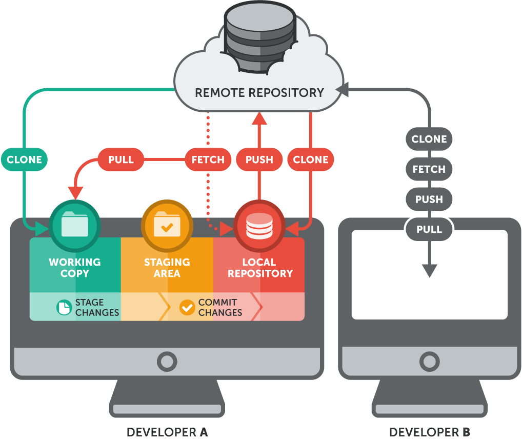

#### Git branch

[figure not shown]

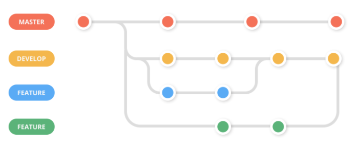

#### Git changes

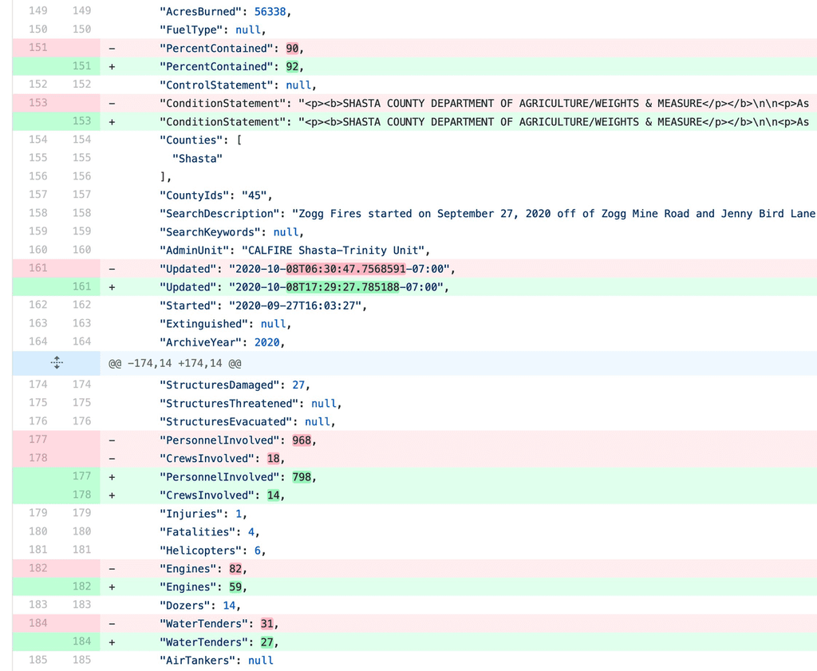

#### Git commit

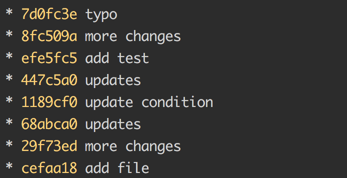

#### Git cheatsheet

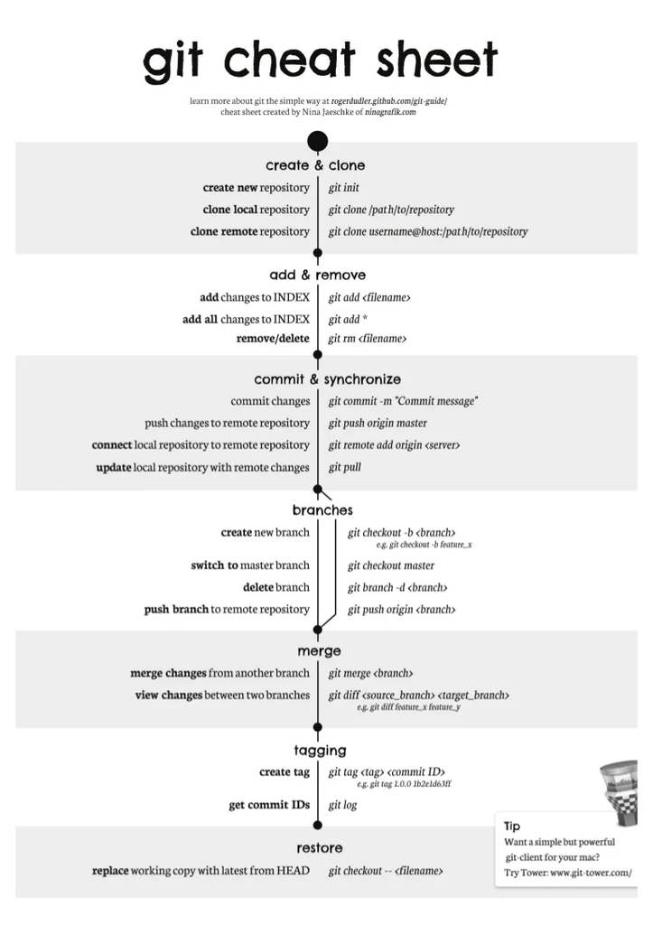

### 1.2. Github introduction

[Github](https://github.com/) is hosting for software development and version control using Git.

#### Github main page

[figure not shown]

#### Create a remote repository

[figure not shown]

#### Repository page

[figure not shown]

## 2. Google Colab introduction

### 2.1. Overall introduction

Google Colab or (Colab for short) is an application developed by Google.  
Colab helps us to run machine learning and especially deep learning models which required lots of computation resources.  
Don't worry about your computer which has no GPU card or low RAM, Colab provide a free resources with Tesla T4 GPU and 12Gb RAM.

### 2.2. Colab instruction

#### Create a new `.ipynb` file on Google Drive

[figure not shown]

#### Change Colab language to English

[figure not shown]

#### Rename `.ipynb` file

[figure not shown]

#### Connect Colab to resources

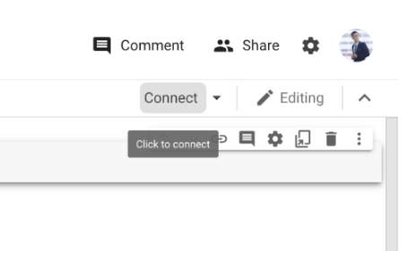

And the result!

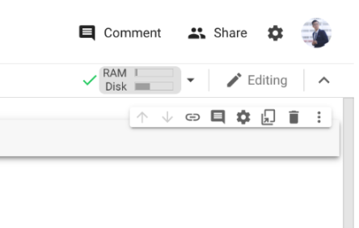

#### Config Colab GPU

[figure not shown]

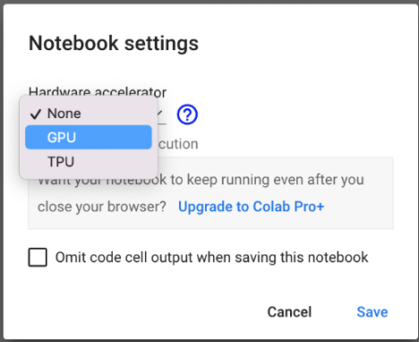

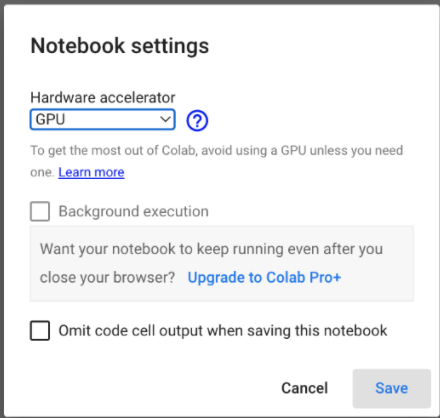

#### Write and run code

Writing and running Python code in Colab is almost similar to using Jupyter notebook.

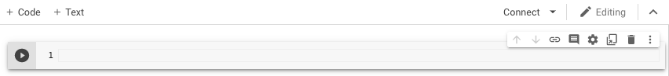

#### Connect to Google Drive

To connect to Google Drive, run the following code

```
from google.colab import drive
drive.mount('/content/gdrive')
```

After running the code, a pop-up will appear. Click `Connect to Google Drive`.

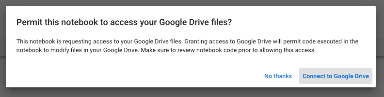

A new browser tab will open. Choose the google account you want to connect.

[figure not shown]

Allow Colab to access to your google account.

[figure not shown]

If everything is ok, you will get the result.

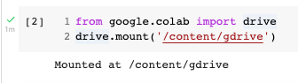

```python
from google.colab import drive
drive.mount('/content/gdrive')
```

#### Check folder tree in Colab

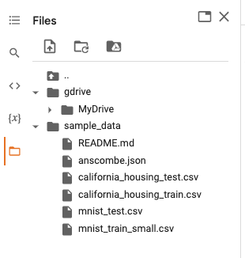

#### Show files in a folder and change folder directory

Run `!ls` to show all files and folders in a folder.  
Run `%cd <PATH/TO/FOLDER>` to change folder directory.

#### Install Python library in Colab

Similar to Jupyter notebook `!conda install -c <CHANNEL_NAME> <PACKAGE_NAME>=<VERSION> -y`